# EncuentrofinalGerenciadeProyectos

**Universidad EAN**

**Gerencia de Proyectos**

Encuentro Final

## **Proyecto: Detección de Empleados sin Casco en Áreas de Trabajo con YOLO**

Profesor:

**Carlos Isaac Zainea**

Preparado por

**Andrés Felipe Sainea Rojas**

**Laura Carolina Mateus Agudelo**

**Daniel Antonio Pérez Beltrán**

*Febrero 28, 2025*

# **Librerías**

Instalación de paquetes, importar las librerías necesarias para la ejecución del notebook

```python
!pip install gdown
!pip install torch
!pip install ultralytics
import gdown
import os
import torch
import yaml
```

[output not shown]

[output cut: 8 more lines]

[output not shown]

# **Datos**

Para usar este modelo se requieren imágenes que son descargadas mediante una búsqueda en *Google Images*. Para ello se han descargado y etiquetado 7000 imágenes. Las imágenes se cargan a la ruta */content/* en el archivo Dataset.zip, el cual será descomprimido para hacer uso de las imágenes.

El folder del dataset debe estar estructurado otros folders que serán usados como datos de entrenamiento, prueba y validación:

# ├── dataset

## └── train

#### └── images (Incluye las imágenes de entrenamiento)

#### └── labels (Incluye las etiquetas de las imágenes de entrenamiento)

## └── test

#### └── images (Incluye las imágenes de prueba)

#### └── labels (Incluye las etiquetas de prueba)

## └── val

#### └── images (Incluye las imágenes de validación)

#### └── labels (Incluye las etiquetas de validación)

```python
file_id = "1lMC00LhK1HMoERpySn5BR5V0U9jLl-hf"
output_path = "/content/datasets.zip"

# Descargar con gdown
gdown.download(f"https://drive.google.com/uc?id={file_id}", output_path, quiet=False)

# Verificar si el archivo es un ZIP válido antes de descomprimir
if os.path.exists(output_path) and os.path.getsize(output_path) > 1000:
    print("✅ Archivo descargado con éxito. Procediendo a descomprimir...")
    !unzip -q "/content/datasets.zip" -d "/content/datasets"
else:
    print("❌ Error: El archivo no se descargó correctamente. Verifica el enlace en Google Drive.")
```

```
Downloading...
From (original): https://drive.google.com/uc?id=1lMC00LhK1HMoERpySn5BR5V0U9jLl-hf
From (redirected): https://drive.google.com/uc?id=1lMC00LhK1HMoERpySn5BR5V0U9jLl-hf&confirm=t&uuid=966d17c0-360b-45f6-b7f9-5b681827debd
To: /content/datasets.zip
```

```
✅ Archivo descargado con éxito. Procediendo a descomprimir...
```

```python
# Verificar que los archivos labels contengan unicamente 2 clases
label_paths = ["/content/datasets/datasets/labels/train", "/content/datasets/datasets/labels/val"]

for path in label_paths:
    for file in os.listdir(path):
        if file.endswith(".txt"):
            file_path = os.path.join(path, file)
            with open(file_path, "r") as f:
                lines = f.readlines()
            new_lines = []
            for line in lines:
                parts = line.split()
                class_id = int(parts[0])
                # Si la clase es mayor a 1, corregirla a 1 (casco)
                if class_id > 1:
                    parts[0] = "1"
                new_lines.append(" ".join(parts) + "\n")
            with open(file_path, "w") as f:
                f.writelines(new_lines)

print("✅ Todas las etiquetas inválidas han sido corregidas.")
```

```
✅ Todas las etiquetas inválidas han sido corregidas.
```

```python
# Creacion de archivo data.yaml
data = {
    'path': './datasets',  # Ruta al dataset clonado
    'train': 'images/train',
    'val': 'images/val',
    'nc': 2,
    'names': ['sin_casco', 'casco']  # Modifica según tus clases
}

with open('/content/datasets/datasets/data.yaml', 'w') as file:
    yaml.dump(data, file,
              default_flow_style=False,
              sort_keys=False)
```

# **YOLOV11**

YOLOv11, desarrollado por Ultralytics y presentado en 2024, es la última evolución de la familia YOLO, mejorando la precisión y velocidad en la detección de objetos en tiempo real. Con una extracción de características más avanzada y optimización para diversos entornos, es ideal para aplicaciones en dispositivos edge, la nube y sistemas con GPU. Esta versión tenía como objetivo mejorar tanto la velocidad como la precisión de las tareas de detección de objetos en comparación con sus predecesoras.

El objetivo de este trabajo es usar este modelo para detección de imágenes de trabajadores usando casco en entornos donde es obligatorio.

### Entrenamiento del modelo

Se procede a realizar el entrenamiento del modelo, el cual, se realiza mediante un comando que contiene los siguientes parámetros:

A continuación, ejecutaremos el comando para entrenar el modelo. Repasemos los indicadores importantes en el siguiente comando:

- **data**: Ruta del archivo YAML del conjunto de datos.
- **img**: Resolución de las imágenes. De forma predeterminada es 640×640.
- **epochs**: Numero de iteraciones completas sobre el conjunto de datos durante el entrenamiento.
- **plots**: Habilita la generacion y almacenamiento de graficos relacionados con el entrenamiento.

```python
from ultralytics import YOLO
model = YOLO("yolo11n.pt")
results = model.train(data="/content/datasets/datasets/data.yaml",
                      epochs=10, # Número de iteraciones
                      imgsz=640, # Tamaño de las imágenes (máxima dimensión)
                      plots=True, # Guardar gráficos de entrenamiento
                      )
```

```
Creating new Ultralytics Settings v0.0.6 file ✅
View Ultralytics Settings with 'yolo settings' or at '/root/.config/Ultralytics/settings.json'
Update Settings with 'yolo settings key=value', i.e. 'yolo settings runs_dir=path/to/dir'. For help see https://docs.ultralytics.com/quickstart/#ultralytics-settings.
Downloading https://github.com/ultralytics/assets/releases/download/v8.3.0/yolo11n.pt to 'yolo11n.pt'...
```

```
Ultralytics 8.3.81 🚀 Python-3.11.11 torch-2.5.1+cu124 CUDA:0 (Tesla T4, 15095MiB)
engine/trainer: task=detect, mode=train, model=yolo11n.pt, data=/content/datasets/datasets/data.yaml, epochs=10, time=None, patience=100, batch=16, imgsz=640, save=True, save_period=-1, cache=False, device=None, workers=8, project=None, name=train, exist_ok=False, pretrained=True, optimizer=auto, ve…
Downloading https://ultralytics.com/assets/Arial.ttf to '/root/.config/Ultralytics/Arial.ttf'...
```

[output not shown]

[output cut: 19 more lines]

```
train: Scanning /content/datasets/datasets/labels/train... 5269 images, 0 backgrounds, 0 corrupt: 100%|██████████| 5269/5269 [00:04<00:00, 1166.99it/s]
```

```
train: New cache created: /content/datasets/datasets/labels/train.cache
albumentations: Blur(p=0.01, blur_limit=(3, 7)), MedianBlur(p=0.01, blur_limit=(3, 7)), ToGray(p=0.01, num_output_channels=3, method='weighted_average'), CLAHE(p=0.01, clip_limit=(1.0, 4.0), tile_grid_size=(8, 8))
```

```
val: New cache created: /content/datasets/datasets/labels/val.cache
Plotting labels to runs/detect/train/labels.jpg...
optimizer: 'optimizer=auto' found, ignoring 'lr0=0.01' and 'momentum=0.937' and determining best 'optimizer', 'lr0' and 'momentum' automatically...
optimizer: AdamW(lr=0.001667, momentum=0.9) with parameter groups 81 weight(decay=0.0), 88 weight(decay=0.0005), 87 bias(decay=0.0)
TensorBoard: model graph visualization added ✅
Image sizes 640 train, 640 val
Using 2 dataloader workers
Logging results to runs/detect/train
Starting training for 10 epochs...
Closing dataloader mosaic
albumentations: Blur(p=0.01, blur_limit=(3, 7)), MedianBlur(p=0.01, blur_limit=(3, 7)), ToGray(p=0.01, num_output_channels=3, method='weighted_average'), CLAHE(p=0.01, clip_limit=(1.0, 4.0), tile_grid_size=(8, 8))

      Epoch    GPU_mem   box_loss   cls_loss   dfl_loss  Instances       Size
```

```
       1/10      2.46G      1.437       1.73      1.187         21        640: 100%|██████████| 330/330 [01:43<00:00,  3.19it/s]
                 Class     Images  Instances      Box(P          R      mAP50  mAP50-95): 100%|██████████| 56/56 [00:16<00:00,  3.31it/s]
```

```
                   all       1766       6808      0.912      0.834      0.913      0.559

      Epoch    GPU_mem   box_loss   cls_loss   dfl_loss  Instances       Size
```

```
       2/10      2.43G      1.378      1.103      1.171         12        640: 100%|██████████| 330/330 [01:38<00:00,  3.35it/s]
                 Class     Images  Instances      Box(P          R      mAP50  mAP50-95): 100%|██████████| 56/56 [00:13<00:00,  4.10it/s]
```

```
                   all       1766       6808        0.9      0.811      0.901      0.575

      Epoch    GPU_mem   box_loss   cls_loss   dfl_loss  Instances       Size
```

```
       3/10      2.36G      1.363     0.9546      1.169         20        640: 100%|██████████| 330/330 [01:36<00:00,  3.42it/s]
                 Class     Images  Instances      Box(P          R      mAP50  mAP50-95): 100%|██████████| 56/56 [00:13<00:00,  4.15it/s]
```

```
                   all       1766       6808      0.902      0.852      0.911      0.584

      Epoch    GPU_mem   box_loss   cls_loss   dfl_loss  Instances       Size
```

```
       4/10      2.41G      1.331     0.8755      1.154         17        640: 100%|██████████| 330/330 [01:36<00:00,  3.41it/s]
                 Class     Images  Instances      Box(P          R      mAP50  mAP50-95): 100%|██████████| 56/56 [00:13<00:00,  4.16it/s]
```

```
                   all       1766       6808       0.92      0.855      0.923      0.591

      Epoch    GPU_mem   box_loss   cls_loss   dfl_loss  Instances       Size
```

```
       5/10      2.38G      1.299     0.8145      1.139         20        640: 100%|██████████| 330/330 [01:35<00:00,  3.45it/s]
                 Class     Images  Instances      Box(P          R      mAP50  mAP50-95): 100%|██████████| 56/56 [00:13<00:00,  4.14it/s]
```

```
                   all       1766       6808      0.921      0.884      0.935      0.614
```

```
      Epoch    GPU_mem   box_loss   cls_loss   dfl_loss  Instances       Size
```

```
       6/10       2.4G      1.272       0.76      1.124         26        640: 100%|██████████| 330/330 [01:39<00:00,  3.33it/s]
                 Class     Images  Instances      Box(P          R      mAP50  mAP50-95): 100%|██████████| 56/56 [00:13<00:00,  4.07it/s]
```

```
                   all       1766       6808      0.937      0.878      0.941      0.625
```

```
      Epoch    GPU_mem   box_loss   cls_loss   dfl_loss  Instances       Size
```

```
       7/10      2.35G      1.245     0.7225      1.108         29        640: 100%|██████████| 330/330 [01:35<00:00,  3.44it/s]
                 Class     Images  Instances      Box(P          R      mAP50  mAP50-95): 100%|██████████| 56/56 [00:13<00:00,  4.15it/s]
```

```
                   all       1766       6808      0.927      0.894      0.947      0.632
```

```
      Epoch    GPU_mem   box_loss   cls_loss   dfl_loss  Instances       Size
```

```
       8/10      2.38G      1.225     0.6757        1.1         24        640: 100%|██████████| 330/330 [01:36<00:00,  3.43it/s]
                 Class     Images  Instances      Box(P          R      mAP50  mAP50-95): 100%|██████████| 56/56 [00:13<00:00,  4.03it/s]
```

```
                   all       1766       6808      0.939      0.901      0.953      0.639
```

```
      Epoch    GPU_mem   box_loss   cls_loss   dfl_loss  Instances       Size
```

```
       9/10      2.34G      1.192     0.6457      1.082         16        640: 100%|██████████| 330/330 [01:35<00:00,  3.45it/s]
                 Class     Images  Instances      Box(P          R      mAP50  mAP50-95): 100%|██████████| 56/56 [00:13<00:00,  4.17it/s]
```

```
                   all       1766       6808      0.937      0.903      0.955      0.641
```

```
      Epoch    GPU_mem   box_loss   cls_loss   dfl_loss  Instances       Size
```

```
      10/10      2.41G      1.175     0.6206      1.073         21        640: 100%|██████████| 330/330 [01:36<00:00,  3.42it/s]
                 Class     Images  Instances      Box(P          R      mAP50  mAP50-95): 100%|██████████| 56/56 [00:14<00:00,  3.95it/s]
```

```
                   all       1766       6808      0.937      0.915      0.959      0.657

10 epochs completed in 0.314 hours.
Optimizer stripped from runs/detect/train/weights/last.pt, 5.4MB
Optimizer stripped from runs/detect/train/weights/best.pt, 5.4MB

Validating runs/detect/train/weights/best.pt...
Ultralytics 8.3.81 🚀 Python-3.11.11 torch-2.5.1+cu124 CUDA:0 (Tesla T4, 15095MiB)
YOLO11n summary (fused): 100 layers, 2,582,542 parameters, 0 gradients, 6.3 GFLOPs
```

```
                 Class     Images  Instances      Box(P          R      mAP50  mAP50-95): 100%|██████████| 56/56 [00:16<00:00,  3.39it/s]
```

```
                   all       1766       6808      0.935      0.916      0.959      0.657
             sin_casco        339       1803      0.917      0.928      0.961       0.66
                 casco       1604       5005      0.953      0.904      0.958      0.654
Speed: 0.2ms preprocess, 1.9ms inference, 0.0ms loss, 1.4ms postprocess per image
Results saved to runs/detect/train
```

Una vez finalizado el entrenamiento, los pesos del modelo se almacenarán en la carpeta */content/runs/detect/train/weights/best.pt*. Por lo tanto, si se desea reutilizar el modelo, este archivo puede ser cargado y empleado para la clasificación sin necesidad de volver a entrenarlo con los mismos parámetros.

### Evaluación del modelo

A continuación se muestran los resultados de la evaluación del modelo

```python
evaluation = model.val()
```

```
Ultralytics 8.3.81 🚀 Python-3.11.11 torch-2.5.1+cu124 CUDA:0 (Tesla T4, 15095MiB)
YOLO11n summary (fused): 100 layers, 2,582,542 parameters, 0 gradients, 6.3 GFLOPs
```

```
val: Scanning /content/datasets/datasets/labels/val.cache... 1766 images, 0 backgrounds, 0 corrupt: 100%|██████████| 1766/1766 [00:00<?, ?it/s]
                 Class     Images  Instances      Box(P          R      mAP50  mAP50-95): 100%|██████████| 111/111 [00:18<00:00,  6.12it/s]
```

```
                   all       1766       6808      0.936      0.916      0.959      0.658
             sin_casco        339       1803      0.918      0.928      0.961      0.661
                 casco       1604       5005      0.954      0.903      0.958      0.655
Speed: 0.4ms preprocess, 3.2ms inference, 0.0ms loss, 1.2ms postprocess per image
Results saved to runs/detect/train2
```

```python
import numpy as np
# Obtener métricas clave
iou = evaluation.box.maps if isinstance(evaluation.box.maps, (list, torch.Tensor, np.ndarray)) else [evaluation.box.maps]
precision = evaluation.box.p.mean() if isinstance(evaluation.box.p, (list, torch.Tensor, np.ndarray)) else evaluation.box.p
recall = evaluation.box.r.mean() if isinstance(evaluation.box.r, (list, torch.Tensor, np.ndarray)) else evaluation.box.r
f1_score = evaluation.box.f1.mean() if isinstance(evaluation.box.f1, (list, torch.Tensor, np.ndarray)) else evaluation.box.f1


# Imprimir métricas
def print_metrics():
    print("📊 Resultados de evaluación:")
    print(f"🔹 mAP (IoU@0.5): {iou[0]:.4f}" if len(iou) > 0 else "🔹 mAP (IoU@0.5): No disponible")
    print(f"🔹 mAP (IoU@0.5:0.95): {iou[1]:.4f}" if len(iou) > 1 else "🔹 mAP (IoU@0.5:0.95): No disponible")
    print(f"🔹 Precisión: {precision:.4f}")
    print(f"🔹 Recall: {recall:.4f}")
    print(f"🔹 F1-score: {f1_score:.4f}")

print_metrics()
print(evaluation)
```

[output not shown]

[output cut: 164 more lines]

### Generación de predicciones con el modelo afinado

```python
model = YOLO('/content/runs/detect/train/weights/best.pt')
model_path = '/content/drive/MyDrive/yolo_model.pt'
model.export(format='torchscript', save_dir='/content/drive/MyDrive')
print(f"✅ Modelo guardado en: {model_path}")
```

```
Ultralytics 8.3.81 🚀 Python-3.11.11 torch-2.5.1+cu124 CPU (Intel Xeon 2.00GHz)
YOLO11n summary (fused): 100 layers, 2,582,542 parameters, 0 gradients, 6.3 GFLOPs

PyTorch: starting from '/content/runs/detect/train/weights/best.pt' with input shape (1, 3, 640, 640) BCHW and output shape(s) (1, 6, 8400) (5.2 MB)

TorchScript: starting export with torch 2.5.1+cu124...
TorchScript: export success ✅ 4.8s, saved as '/content/runs/detect/train/weights/best.torchscript' (10.4 MB)

Export complete (8.0s)
Results saved to /content/runs/detect/train/weights
Predict:         yolo predict task=detect model=/content/runs/detect/train/weights/best.torchscript imgsz=640
Validate:        yolo val task=detect model=/content/runs/detect/train/weights/best.torchscript imgsz=640 data=/content/datasets/datasets/data.yaml
Visualize:       https://netron.app
✅ Modelo guardado en: /content/drive/MyDrive/yolo_model.pt
```

```python
preds = model('/content/datasets/datasets/images/test')
```

```
image 1/75 /content/datasets/datasets/images/test/000002.jpg: 384x640 3 cascos, 47.3ms
image 2/75 /content/datasets/datasets/images/test/000004.jpg: 448x640 2 cascos, 48.4ms
image 3/75 /content/datasets/datasets/images/test/000005.jpg: 480x640 3 cascos, 49.1ms
image 4/75 /content/datasets/datasets/images/test/000006.jpg: 544x640 2 cascos, 49.6ms
image 5/75 /content/datasets/datasets/images/test/000007.jpg: 480x640 1 sin_casco, 6 cascos, 9.5ms
image 6/75 /content/datasets/datasets/images/test/000008.jpg: 480x640 1 sin_casco, 9.0ms
image 7/75 /content/datasets/datasets/images/test/000009.jpg: 448x640 2 cascos, 18.8ms
image 8/75 /content/datasets/datasets/images/test/000010.png: 448x640 3 sin_cascos, 5 cascos, 9.1ms
image 9/75 /content/datasets/datasets/images/test/000012.jpg: 448x640 2 cascos, 9.1ms
image 10/75 /content/datasets/datasets/images/test/000013.jpg: 416x640 3 cascos, 48.9ms
image 11/75 /content/datasets/datasets/images/test/000014.jpg: 480x640 1 casco, 9.5ms
image 12/75 /content/datasets/datasets/images/test/000015.jpg: 448x640 2 cascos, 9.6ms
image 13/75 /content/datasets/datasets/images/test/000016.jpg: 448x640 2 cascos, 9.0ms
image 14/75 /content/datasets/datasets/images/test/000018.png: 480x640 1 casco, 9.2ms
image 15/75 /content/datasets/datasets/images/test/000020.jpg: 448x640 2 cascos, 10.7ms
image 16/75 /content/datasets/datasets/images/test/000022.jpg: 384x640 3 cascos, 15.1ms
image 17/75 /content/datasets/datasets/images/test/000023.png: 448x640 1 casco, 9.6ms
image 18/75 /content/datasets/datasets/images/test/000024.jpg: 640x448 1 casco, 54.9ms
image 19/75 /content/datasets/datasets/images/test/000025.jpg: 480x640 1 casco, 10.3ms
image 20/75 /content/datasets/datasets/images/test/000026.jpg: 448x640 1 casco, 10.3ms
image 21/75 /content/datasets/datasets/images/test/000029.jpg: 480x640 1 casco, 10.0ms
image 22/75 /content/datasets/datasets/images/test/000030.jpg: 640x640 2 cascos, 10.3ms
image 23/75 /content/datasets/datasets/images/test/000031.jpg: 448x640 1 casco, 9.7ms
image 24/75 /content/datasets/datasets/images/test/000037.jpg: 480x640 1 casco, 10.4ms
image 25/75 /content/datasets/datasets/images/test/000038.jpg: 448x640 1 casco, 10.3ms
image 26/75 /content/datasets/datasets/images/test/000039.jpg: 448x640 2 cascos, 8.8ms
image 27/75 /content/datasets/datasets/images/test/000042.jpg: 640x640 1 casco, 9.7ms
image 28/75 /content/datasets/datasets/images/test/000043.jpg: 448x640 5 cascos, 10.1ms
image 29/75 /content/datasets/datasets/images/test/000044.jpg: 384x640 4 cascos, 10.3ms
image 30/75 /content/datasets/datasets/images/test/000045.jpg: 480x640 2 cascos, 10.6ms
image 31/75 /content/datasets/datasets/images/test/000046.jpg: 384x640 1 sin_casco, 10 cascos, 10.5ms
image 32/75 /content/datasets/datasets/images/test/000502.jpg: 384x640 3 cascos, 9.6ms
image 33/75 /content/datasets/datasets/images/test/000504.jpg: 448x640 2 cascos, 9.9ms
image 34/75 /content/datasets/datasets/images/test/000505.jpg: 480x640 3 cascos, 9.9ms
image 35/75 /content/datasets/datasets/images/test/000506.jpg: 544x640 2 cascos, 12.1ms
image 36/75 /content/datasets/datasets/images/test/000507.jpg: 480x640 1 sin_casco, 6 cascos, 11.3ms
image 37/75 /content/datasets/datasets/images/test/000508.jpg: 480x640 1 sin_casco, 9.2ms
image 38/75 /content/datasets/datasets/images/test/000509.jpg: 448x640 2 cascos, 9.4ms
image 39/75 /content/datasets/datasets/images/test/000510.jpg: 448x640 2 cascos, 9.6ms
image 40/75 /content/datasets/datasets/images/test/000510.png: 448x640 3 sin_cascos, 5 cascos, 10.8ms
```

[output cut: 21 more lines]

```
image 62/75 /content/datasets/datasets/images/test/000542.jpg: 448x640 1 casco, 9.3ms
image 63/75 /content/datasets/datasets/images/test/000543.jpg: 448x640 2 cascos, 9.5ms
image 64/75 /content/datasets/datasets/images/test/000546.jpg: 640x640 1 casco, 9.6ms
image 65/75 /content/datasets/datasets/images/test/000547.jpg: 448x640 5 cascos, 9.3ms
image 66/75 /content/datasets/datasets/images/test/000548.jpg: 448x640 1 casco, 9.0ms
image 67/75 /content/datasets/datasets/images/test/000550.jpg: 480x640 2 cascos, 13.4ms
image 68/75 /content/datasets/datasets/images/test/000551.jpg: 384x640 1 sin_casco, 10 cascos, 12.3ms
image 69/75 /content/datasets/datasets/images/test/000552.jpg: 480x640 2 cascos, 14.9ms
image 70/75 /content/datasets/datasets/images/test/000554.jpg: 448x640 2 cascos, 15.0ms
image 71/75 /content/datasets/datasets/images/test/000557.jpg: 448x640 1 casco, 11.9ms
image 72/75 /content/datasets/datasets/images/test/000559.jpg: 640x640 2 sin_cascos, 4 cascos, 9.6ms
image 73/75 /content/datasets/datasets/images/test/000562.jpg: 480x640 1 sin_casco, 9.7ms
image 74/75 /content/datasets/datasets/images/test/000563.jpg: 448x640 1 casco, 9.1ms
image 75/75 /content/datasets/datasets/images/test/000565.jpg: 448x640 2 cascos, 10.8ms
Speed: 2.5ms preprocess, 13.6ms inference, 1.3ms postprocess per image at shape (1, 3, 448, 640)
```

### Muestra de predicciones

[figure not shown]

```python
preds[11].show()
```

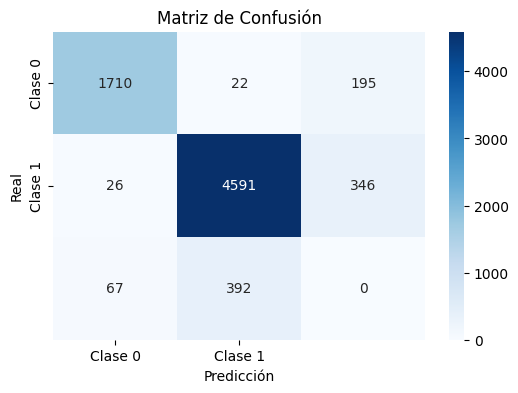

```python
import matplotlib.pyplot as plt
import seaborn as sns
# Obtener la matriz de confusión
conf_matrix = evaluation.confusion_matrix.matrix

# Definir etiquetas
labels = ["Clase 0", "Clase 1"]

# Graficar la matriz de confusión
plt.figure(figsize=(6, 4))
sns.heatmap(conf_matrix, annot=True, fmt=".0f", cmap="Blues", xticklabels=labels, yticklabels=labels)
plt.xlabel("Predicción")
plt.ylabel("Real")
plt.title("Matriz de Confusión")
plt.show()
```

```python
print("Atributos disponibles en evaluation:")
print(dir(evaluation))

print("\nAtributos en confusion_matrix:")
print(dir(evaluation.confusion_matrix) if hasattr(evaluation, "confusion_matrix") else "No disponible")

print("\nAtributos en box:")
print(dir(evaluation.box) if hasattr(evaluation, "box") else "No disponible")
```

[output not shown]

```python
print("Valores en p (precisión):", evaluation.box.p)
print("Valores en r (recall):", evaluation.box.r)
```

```
Valores en p (precisión): [    0.91811      0.9544]
Valores en r (recall): [     0.9279     0.90317]
```

```
y_true: [1 1 1 1 1 1 1 1 1 1]
y_scores: [    0.88706     0.86014     0.85555     0.91028     0.90613     0.77759      0.7551     0.72103     0.84433     0.84134]
```

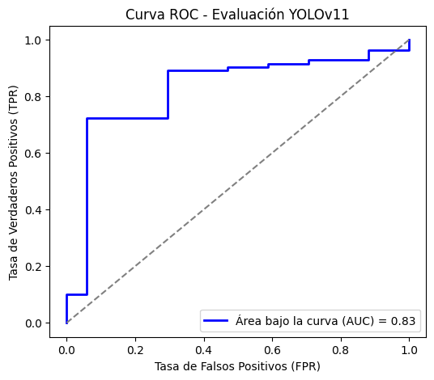

```python
import numpy as np
from sklearn.metrics import roc_curve, auc
import matplotlib.pyplot as plt
from ultralytics import YOLO

y_true = []  # Etiquetas reales
y_scores = []  # Puntajes de confianza

for pred in preds:
    for box in pred.boxes:
        y_true.append(int(box.cls))  # Clase real de la predicción
        y_scores.append(float(box.conf))  # Puntuación de confianza

# Convertir a arrays numpy
y_true = np.array(y_true)
y_scores = np.array(y_scores)

# Verificar dimensiones
print("y_true:", y_true[:10])  # Primeras 10 etiquetas reales
print("y_scores:", y_scores[:10])  # Primeras 10 probabilidades

# Generar Curva ROC si los datos son correctos
if len(y_true) > 0 and len(y_scores) > 0:
    fpr, tpr, _ = roc_curve(y_true, y_scores, pos_label=1)
    roc_auc = auc(fpr, tpr)

    # Graficar curva ROC
    plt.figure(figsize=(6, 5))
    plt.plot(fpr, tpr, color='blue', lw=2, label=f'Área bajo la curva (AUC) = {roc_auc:.2f}')
    plt.plot([0, 1], [0, 1], color='gray', linestyle='--')
    plt.xlabel("Tasa de Falsos Positivos (FPR)")
    plt.ylabel("Tasa de Verdaderos Positivos (TPR)")
    plt.title("Curva ROC - Evaluación YOLOv11")
    plt.legend(loc="lower right")
    plt.show()
else:
    print("⚠️ No se pudo generar la curva ROC porque los valores no son correctos.")
```